# Risk Factor Analysis

## Outcome Variable

**Outcome Variable:** ever_stunted

## Predictor Variables

**Intervention Variable:** nhh

**Adjustment Set:**

unadjusted

## Stratifying Variables

The analysis was stratified on these variable(s):

- agecat
- studyid

The following strata were considered:

- agecat: 12 months, studyid: ki1000108-IRC
- agecat: 12 months, studyid: ki1000304b-SAS-FoodSuppl
- agecat: 12 months, studyid: ki1017093-NIH-Birth
- agecat: 12 months, studyid: ki1017093c-NIH-Crypto
- agecat: 12 months, studyid: ki1148112-LCNI-5
- agecat: 18 months, studyid: ki1000108-IRC
- agecat: 18 months, studyid: ki1000304b-SAS-FoodSuppl
- agecat: 18 months, studyid: ki1017093-NIH-Birth
- agecat: 18 months, studyid: ki1017093c-NIH-Crypto
- agecat: 18 months, studyid: ki1148112-LCNI-5
- agecat: 24 months, studyid: ki1000108-IRC
- agecat: 24 months, studyid: ki1000304b-SAS-FoodSuppl
- agecat: 24 months, studyid: ki1017093-NIH-Birth
- agecat: 24 months, studyid: ki1017093c-NIH-Crypto
- agecat: 24 months, studyid: ki1148112-LCNI-5
- agecat: 3 months, studyid: ki1000108-IRC
- agecat: 3 months, studyid: ki1017093-NIH-Birth
- agecat: 3 months, studyid: ki1017093c-NIH-Crypto
- agecat: 6 months, studyid: ki1000108-IRC
- agecat: 6 months, studyid: ki1000304b-SAS-FoodSuppl
- agecat: 6 months, studyid: ki1017093-NIH-Birth
- agecat: 6 months, studyid: ki1017093c-NIH-Crypto
- agecat: 6 months, studyid: ki1148112-LCNI-5

## Methods Detail

# Results Detail

## Results Plots

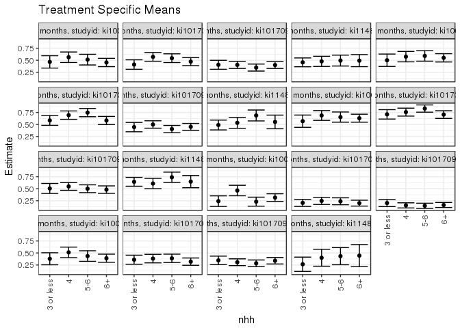

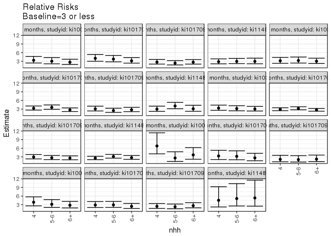

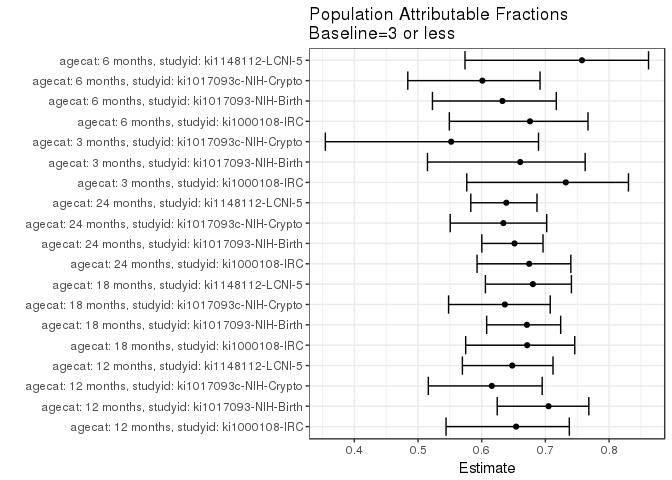

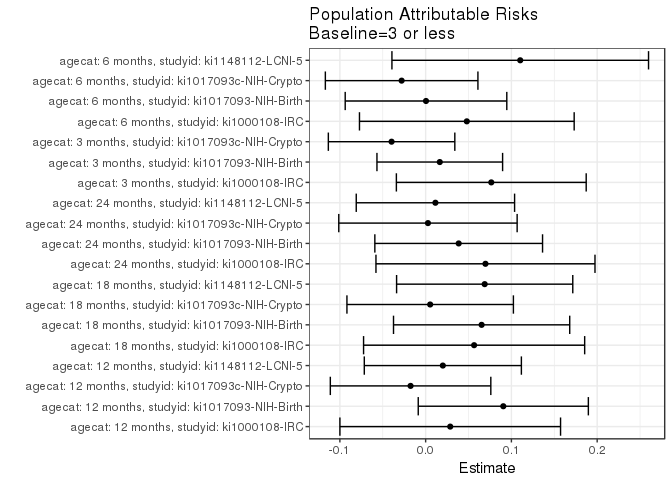

## Data Summary

| agecat | studyid | A | n | nA | nAY0 | nAY1 |
| --- | --- | --- | --- | --- | --- | --- |
| 12 months | ki1000108-IRC | 3 or less | 344 | 58 | 31 | 27 |
| 12 months | ki1000108-IRC | 4 | 344 | 80 | 35 | 45 |
| 12 months | ki1000108-IRC | 5-6 | 344 | 78 | 38 | 40 |
| 12 months | ki1000108-IRC | 6+ | 344 | 128 | 70 | 58 |
| 12 months | ki1000304b-SAS-FoodSuppl | 3 or less | 75 | 8 | 3 | 5 |
| 12 months | ki1000304b-SAS-FoodSuppl | 4 | 75 | 15 | 0 | 15 |
| 12 months | ki1000304b-SAS-FoodSuppl | 5-6 | 75 | 23 | 4 | 19 |
| 12 months | ki1000304b-SAS-FoodSuppl | 6+ | 75 | 29 | 3 | 26 |
| 12 months | ki1017093-NIH-Birth | 3 or less | 465 | 95 | 56 | 39 |
| 12 months | ki1017093-NIH-Birth | 4 | 465 | 114 | 49 | 65 |
| 12 months | ki1017093-NIH-Birth | 5-6 | 465 | 116 | 53 | 63 |
| 12 months | ki1017093-NIH-Birth | 6+ | 465 | 140 | 74 | 66 |
| 12 months | ki1017093c-NIH-Crypto | 3 or less | 621 | 106 | 63 | 43 |
| 12 months | ki1017093c-NIH-Crypto | 4 | 621 | 166 | 99 | 67 |
| 12 months | ki1017093c-NIH-Crypto | 5-6 | 621 | 164 | 107 | 57 |
| 12 months | ki1017093c-NIH-Crypto | 6+ | 621 | 185 | 111 | 74 |
| 12 months | ki1148112-LCNI-5 | 3 or less | 336 | 114 | 62 | 52 |
| 12 months | ki1148112-LCNI-5 | 4 | 336 | 86 | 45 | 41 |
| 12 months | ki1148112-LCNI-5 | 5-6 | 336 | 75 | 38 | 37 |
| 12 months | ki1148112-LCNI-5 | 6+ | 336 | 61 | 31 | 30 |
| 18 months | ki1000108-IRC | 3 or less | 345 | 58 | 29 | 29 |
| 18 months | ki1000108-IRC | 4 | 345 | 80 | 34 | 46 |
| 18 months | ki1000108-IRC | 5-6 | 345 | 78 | 32 | 46 |
| 18 months | ki1000108-IRC | 6+ | 345 | 129 | 58 | 71 |
| 18 months | ki1000304b-SAS-FoodSuppl | 3 or less | 70 | 7 | 1 | 6 |
| 18 months | ki1000304b-SAS-FoodSuppl | 4 | 70 | 15 | 1 | 14 |
| 18 months | ki1000304b-SAS-FoodSuppl | 5-6 | 70 | 21 | 2 | 19 |
| 18 months | ki1000304b-SAS-FoodSuppl | 6+ | 70 | 27 | 2 | 25 |
| 18 months | ki1017093-NIH-Birth | 3 or less | 428 | 89 | 37 | 52 |
| 18 months | ki1017093-NIH-Birth | 4 | 428 | 108 | 33 | 75 |

[output cut: 70 more lines]

## Results Table

### Parameter: TSM

| agecat | studyid | intervention_level | baseline_level | estimate | ci_lower | ci_upper |
| --- | --- | --- | --- | --- | --- | --- |
| 12 months | ki1000108-IRC | 3 or less | NA | 0.4655172 | 0.3369587 | 0.5940758 |
| 12 months | ki1000108-IRC | 4 | NA | 0.5625000 | 0.4536357 | 0.6713643 |
| 12 months | ki1000108-IRC | 5-6 | NA | 0.5128205 | 0.4017343 | 0.6239067 |
| 12 months | ki1000108-IRC | 6+ | NA | 0.4531250 | 0.3667619 | 0.5394881 |
| 12 months | ki1017093-NIH-Birth | 3 or less | NA | 0.4105263 | 0.3114987 | 0.5095540 |
| 12 months | ki1017093-NIH-Birth | 4 | NA | 0.5701754 | 0.4792023 | 0.6611485 |
| 12 months | ki1017093-NIH-Birth | 5-6 | NA | 0.5431034 | 0.4523555 | 0.6338514 |
| 12 months | ki1017093-NIH-Birth | 6+ | NA | 0.4714286 | 0.3886513 | 0.5542059 |
| 12 months | ki1017093c-NIH-Crypto | 3 or less | NA | 0.4056604 | 0.3121104 | 0.4992104 |
| 12 months | ki1017093c-NIH-Crypto | 4 | NA | 0.4036145 | 0.3289196 | 0.4783094 |
| 12 months | ki1017093c-NIH-Crypto | 5-6 | NA | 0.3475610 | 0.2746217 | 0.4205003 |
| 12 months | ki1017093c-NIH-Crypto | 6+ | NA | 0.4000000 | 0.3293491 | 0.4706509 |
| 12 months | ki1148112-LCNI-5 | 3 or less | NA | 0.4561404 | 0.3645741 | 0.5477066 |
| 12 months | ki1148112-LCNI-5 | 4 | NA | 0.4767442 | 0.3710269 | 0.5824614 |
| 12 months | ki1148112-LCNI-5 | 5-6 | NA | 0.4933333 | 0.3800161 | 0.6066506 |
| 12 months | ki1148112-LCNI-5 | 6+ | NA | 0.4918033 | 0.3661592 | 0.6174474 |
| 18 months | ki1000108-IRC | 3 or less | NA | 0.5000000 | 0.3711352 | 0.6288648 |
| 18 months | ki1000108-IRC | 4 | NA | 0.5750000 | 0.4665170 | 0.6834830 |
| 18 months | ki1000108-IRC | 5-6 | NA | 0.5897436 | 0.4804259 | 0.6990613 |
| 18 months | ki1000108-IRC | 6+ | NA | 0.5503876 | 0.4644196 | 0.6363556 |
| 18 months | ki1017093-NIH-Birth | 3 or less | NA | 0.5842697 | 0.4817579 | 0.6867814 |
| 18 months | ki1017093-NIH-Birth | 4 | NA | 0.6944444 | 0.6074667 | 0.7814222 |
| 18 months | ki1017093-NIH-Birth | 5-6 | NA | 0.7474747 | 0.6617928 | 0.8331567 |
| 18 months | ki1017093-NIH-Birth | 6+ | NA | 0.5833333 | 0.4991314 | 0.6675352 |
| 18 months | ki1017093c-NIH-Crypto | 3 or less | NA | 0.4455446 | 0.3485332 | 0.5425559 |
| 18 months | ki1017093c-NIH-Crypto | 4 | NA | 0.5000000 | 0.4229422 | 0.5770578 |
| 18 months | ki1017093c-NIH-Crypto | 5-6 | NA | 0.4049080 | 0.3294890 | 0.4803270 |
| 18 months | ki1017093c-NIH-Crypto | 6+ | NA | 0.4510870 | 0.3791292 | 0.5230447 |
| 18 months | ki1148112-LCNI-5 | 3 or less | NA | 0.4891304 | 0.3867988 | 0.5914620 |
| 18 months | ki1148112-LCNI-5 | 4 | NA | 0.5342466 | 0.4196099 | 0.6488833 |
| 18 months | ki1148112-LCNI-5 | 5-6 | NA | 0.6875000 | 0.5737353 | 0.8012647 |
| 18 months | ki1148112-LCNI-5 | 6+ | NA | 0.5531915 | 0.4107994 | 0.6955836 |
| 24 months | ki1000108-IRC | 3 or less | NA | 0.5689655 | 0.4413329 | 0.6965981 |
| 24 months | ki1000108-IRC | 4 | NA | 0.6875000 | 0.5857831 | 0.7892169 |
| 24 months | ki1000108-IRC | 5-6 | NA | 0.6538462 | 0.5481153 | 0.7595770 |
| 24 months | ki1000108-IRC | 6+ | NA | 0.6307692 | 0.5476906 | 0.7138478 |
| 24 months | ki1017093-NIH-Birth | 3 or less | NA | 0.7108434 | 0.6131879 | 0.8084989 |
| 24 months | ki1017093-NIH-Birth | 4 | NA | 0.7572816 | 0.6743836 | 0.8401795 |
| 24 months | ki1017093-NIH-Birth | 5-6 | NA | 0.8315789 | 0.7562312 | 0.9069267 |
| 24 months | ki1017093-NIH-Birth | 6+ | NA | 0.7063492 | 0.6267292 | 0.7859692 |
| 24 months | ki1017093c-NIH-Crypto | 3 or less | NA | 0.5056180 | 0.4016505 | 0.6095854 |
| 24 months | ki1017093c-NIH-Crypto | 4 | NA | 0.5479452 | 0.4671403 | 0.6287501 |
| 24 months | ki1017093c-NIH-Crypto | 5-6 | NA | 0.5000000 | 0.4188211 | 0.5811789 |
| 24 months | ki1017093c-NIH-Crypto | 6+ | NA | 0.4812500 | 0.4037585 | 0.5587415 |
| 24 months | ki1148112-LCNI-5 | 3 or less | NA | 0.6442308 | 0.5520678 | 0.7363938 |
| 24 months | ki1148112-LCNI-5 | 4 | NA | 0.6075949 | 0.4997427 | 0.7154472 |
| 24 months | ki1148112-LCNI-5 | 5-6 | NA | 0.7384615 | 0.6314469 | 0.8454762 |
| 24 months | ki1148112-LCNI-5 | 6+ | NA | 0.6481481 | 0.5205664 | 0.7757299 |
| 3 months | ki1000108-IRC | 3 or less | NA | 0.2413793 | 0.1310921 | 0.3516665 |
| 3 months | ki1000108-IRC | 4 | NA | 0.4625000 | 0.3530850 | 0.5719150 |
| 3 months | ki1000108-IRC | 5-6 | NA | 0.2307692 | 0.1371324 | 0.3244060 |
| 3 months | ki1000108-IRC | 6+ | NA | 0.3153846 | 0.2353923 | 0.3953770 |
| 3 months | ki1017093-NIH-Birth | 3 or less | NA | 0.2051282 | 0.1318939 | 0.2783625 |
| 3 months | ki1017093-NIH-Birth | 4 | NA | 0.2461538 | 0.1720366 | 0.3202711 |
| 3 months | ki1017093-NIH-Birth | 5-6 | NA | 0.2388060 | 0.1665516 | 0.3110603 |
| 3 months | ki1017093-NIH-Birth | 6+ | NA | 0.2000000 | 0.1389108 | 0.2610892 |
| 3 months | ki1017093c-NIH-Crypto | 3 or less | NA | 0.2017544 | 0.1280301 | 0.2754787 |
| 3 months | ki1017093c-NIH-Crypto | 4 | NA | 0.1534091 | 0.1001260 | 0.2066922 |
| 3 months | ki1017093c-NIH-Crypto | 5-6 | NA | 0.1445783 | 0.0910392 | 0.1981174 |
| 3 months | ki1017093c-NIH-Crypto | 6+ | NA | 0.1614583 | 0.1093718 | 0.2135449 |
| 6 months | ki1000108-IRC | 3 or less | NA | 0.3793103 | 0.2542554 | 0.5043653 |
| 6 months | ki1000108-IRC | 4 | NA | 0.5125000 | 0.4028094 | 0.6221906 |
| 6 months | ki1000108-IRC | 5-6 | NA | 0.4358974 | 0.3256917 | 0.5461032 |
| 6 months | ki1000108-IRC | 6+ | NA | 0.3906250 | 0.3059807 | 0.4752693 |
| 6 months | ki1017093-NIH-Birth | 3 or less | NA | 0.3600000 | 0.2658236 | 0.4541764 |
| 6 months | ki1017093-NIH-Birth | 4 | NA | 0.3826087 | 0.2936866 | 0.4715308 |
| 6 months | ki1017093-NIH-Birth | 5-6 | NA | 0.3884298 | 0.3014961 | 0.4753634 |
| 6 months | ki1017093-NIH-Birth | 6+ | NA | 0.3194444 | 0.2432104 | 0.3956785 |
| 6 months | ki1017093c-NIH-Crypto | 3 or less | NA | 0.3454545 | 0.2565217 | 0.4343874 |
| 6 months | ki1017093c-NIH-Crypto | 4 | NA | 0.3072289 | 0.2369921 | 0.3774657 |
| 6 months | ki1017093c-NIH-Crypto | 5-6 | NA | 0.2848485 | 0.2159266 | 0.3537704 |
| 6 months | ki1017093c-NIH-Crypto | 6+ | NA | 0.3386243 | 0.2711023 | 0.4061463 |
| 6 months | ki1148112-LCNI-5 | 3 or less | NA | 0.2647059 | 0.1157463 | 0.4136655 |
| 6 months | ki1148112-LCNI-5 | 4 | NA | 0.4000000 | 0.2239076 | 0.5760924 |
| 6 months | ki1148112-LCNI-5 | 5-6 | NA | 0.4333333 | 0.2552145 | 0.6114522 |
| 6 months | ki1148112-LCNI-5 | 6+ | NA | 0.4444444 | 0.2138590 | 0.6750299 |

### Parameter: E(Y)

| agecat | studyid | intervention_level | baseline_level | estimate | ci_lower | ci_upper |
| --- | --- | --- | --- | --- | --- | --- |
| 12 months | ki1000108-IRC | NA | NA | 0.4941860 | 0.4895369 | 0.4988352 |
| 12 months | ki1017093-NIH-Birth | NA | NA | 0.5010753 | 0.4956532 | 0.5064973 |
| 12 months | ki1017093c-NIH-Crypto | NA | NA | 0.3880837 | 0.3861666 | 0.3900008 |
| 12 months | ki1148112-LCNI-5 | NA | NA | 0.4761905 | 0.4745098 | 0.4778711 |
| 18 months | ki1000108-IRC | NA | NA | 0.5565217 | 0.5533872 | 0.5596563 |
| 18 months | ki1017093-NIH-Birth | NA | NA | 0.6495327 | 0.6428493 | 0.6562161 |
| 18 months | ki1017093c-NIH-Crypto | NA | NA | 0.4508197 | 0.4480567 | 0.4535826 |
| 18 months | ki1148112-LCNI-5 | NA | NA | 0.5579710 | 0.5491084 | 0.5668337 |
| 24 months | ki1000108-IRC | NA | NA | 0.6387283 | 0.6347225 | 0.6427341 |
| 24 months | ki1017093-NIH-Birth | NA | NA | 0.7493857 | 0.7445524 | 0.7542191 |
| 24 months | ki1017093c-NIH-Crypto | NA | NA | 0.5083179 | 0.5061505 | 0.5104853 |
| 24 months | ki1148112-LCNI-5 | NA | NA | 0.6556291 | 0.6504091 | 0.6608491 |
| 3 months | ki1000108-IRC | NA | NA | 0.3179191 | 0.3087625 | 0.3270756 |
| 3 months | ki1017093-NIH-Birth | NA | NA | 0.2216117 | 0.2199007 | 0.2233227 |
| 3 months | ki1017093c-NIH-Crypto | NA | NA | 0.1620370 | 0.1605431 | 0.1635310 |
| 6 months | ki1000108-IRC | NA | NA | 0.4273256 | 0.4219359 | 0.4327152 |
| 6 months | ki1017093-NIH-Birth | NA | NA | 0.3604167 | 0.3578531 | 0.3629802 |
| 6 months | ki1017093c-NIH-Crypto | NA | NA | 0.3174603 | 0.3155826 | 0.3193381 |
| 6 months | ki1148112-LCNI-5 | NA | NA | 0.3750000 | 0.3611450 | 0.3888550 |

### Parameter: RR

[output not shown]

### Parameter: PAR

| agecat | studyid | intervention_level | baseline_level | estimate | ci_lower | ci_upper |
| --- | --- | --- | --- | --- | --- | --- |
| 12 months | ki1000108-IRC | 3 or less | NA | 0.0286688 | -0.0999738 | 0.1573114 |
| 12 months | ki1017093-NIH-Birth | 3 or less | NA | 0.0905490 | -0.0086270 | 0.1897249 |
| 12 months | ki1017093c-NIH-Crypto | 3 or less | NA | -0.0175766 | -0.1111463 | 0.0759930 |
| 12 months | ki1148112-LCNI-5 | 3 or less | NA | 0.0200501 | -0.0715316 | 0.1116318 |
| 18 months | ki1000108-IRC | 3 or less | NA | 0.0565217 | -0.0723812 | 0.1854247 |
| 18 months | ki1017093-NIH-Birth | 3 or less | NA | 0.0652630 | -0.0374663 | 0.1679924 |
| 18 months | ki1017093c-NIH-Crypto | 3 or less | NA | 0.0052751 | -0.0917756 | 0.1023258 |
| 18 months | ki1148112-LCNI-5 | 3 or less | NA | 0.0688406 | -0.0338741 | 0.1715552 |
| 24 months | ki1000108-IRC | 3 or less | NA | 0.0697628 | -0.0579326 | 0.1974582 |
| 24 months | ki1017093-NIH-Birth | 3 or less | NA | 0.0385424 | -0.0592327 | 0.1363174 |
| 24 months | ki1017093c-NIH-Crypto | 3 or less | NA | 0.0027000 | -0.1012901 | 0.1066900 |
| 24 months | ki1148112-LCNI-5 | 3 or less | NA | 0.0113984 | -0.0809123 | 0.1037091 |
| 3 months | ki1000108-IRC | 3 or less | NA | 0.0765398 | -0.0341269 | 0.1872064 |
| 3 months | ki1017093-NIH-Birth | 3 or less | NA | 0.0164835 | -0.0567708 | 0.0897378 |
| 3 months | ki1017093c-NIH-Crypto | 3 or less | NA | -0.0397173 | -0.1134568 | 0.0340221 |
| 6 months | ki1000108-IRC | 3 or less | NA | 0.0480152 | -0.0771558 | 0.1731863 |
| 6 months | ki1017093-NIH-Birth | 3 or less | NA | 0.0004167 | -0.0937946 | 0.0946280 |
| 6 months | ki1017093c-NIH-Crypto | 3 or less | NA | -0.0279942 | -0.1169469 | 0.0609584 |
| 6 months | ki1148112-LCNI-5 | 3 or less | NA | 0.1102941 | -0.0393084 | 0.2598967 |

### Parameter: PAF

[output not shown]